# Practcal Machine learning - Project Writeup

Guy Mathys

9 februari 2016

# 1. Background

Using devices such as Jawbone Up, Nike FuelBand, and Fitbit it is now possible to collect a large amount of data about personal activity relatively inexpensively. These type of devices are part of the quantified self movement.

More information is available from the website http://groupware.les.inf.puc-rio.br/har

# 2. Project

The goal of this project is to predict the manner in which the participants did the exercise. This is the classe variable of the training set, which classifies the correct and incorrect outcomes into A, B, C, D, and E categories. This report describes how the model for the project was built, its cross validation, expected out of sample error calculation, and the choices made. It was used successfully to accurately predict all 20 different test cases on the Coursera website.

# 3. Data

## 3.1. Source of data

The training data for this project are available here: https://d396qusza40orc.cloudfront.net/predmachlearn/pml-training.csv The test data are available here: https://d396qusza40orc.cloudfront.net/predmachlearn/pml-testing.csv The data for this project come from this source: http://groupware.les.inf.puc-rio.br/har.

## 3.2. Loading Data

Download the training data interpreting the miscellaneous NA, #DIV/0! and empty fields as NA.

```r
#Loading library used.
library(caret)
library(randomForest)
```

```r
library(ggplot2)
library(lattice)
library(rpart.plot)
set.seed(4232206)

#Clearing Workspace
rm(list=ls())
setwd("C:/Users/Guy Mathys/Documents/GitHub")

# Load the training data set
trainingData<- read.csv("pml-training.csv", na.strings = c("NA", "#DIV/0!", ""))
```

## 3.3 Exploring and Cleaning Data

```r
# Number of columns
ncol(trainingData)
```

```
## [1] 160
```

```r
# Number of rows
nrow(trainingData)
```

```
## [1] 19622
```

```r
# Summary
summary(trainingData[,c(1:2,159:160)])
```

```
##        X            user_name    magnet_forearm_z classe
##  Min.   :    1   adelmo  :3892   Min.   :-973.0   A:5580
##  1st Qu.: 4906   carlitos:3112   1st Qu.: 191.0   B:3797
##  Median : 9812   charles :3536   Median : 511.0   C:3422
##  Mean   : 9812   eurico  :3070   Mean   : 393.6   D:3216
##  3rd Qu.:14717   jeremy  :3402   3rd Qu.: 653.0   E:3607
##  Max.   :19622   pedro   :2610   Max.   :1090.0
```

```r
str(trainingData, list.len=15)
```

```
## 'data.frame':    19622 obs. of  160 variables:
##  $ X                       : int  1 2 3 4 5 6 7 8 9 10 ...
##  $ user_name               : Factor w/ 6 levels "adelmo","carlitos",..: 2 2 2 2 2 2 2 2 2 2 ...
##  $ raw_timestamp_part_1    : int  1323084231 1323084231 1323084231 1323084232 1323084232 1323084232 1323084232 1323084232 1323084232 1323084232 ...
##  $ raw_timestamp_part_2    : int  788290 808298 820366 120339 196328 304277 368296 440390 484323 484434 ...
##  $ cvtd_timestamp          : Factor w/ 20 levels "02/12/2011 13:32",..: 9 9 9 9 9 9 9 9 9 9 ...
##  $ new_window              : Factor w/ 2 levels "no","yes": 1 1 1 1 1 1 1 1 1 1 ...
##  $ num_window              : int  11 11 11 12 12 12 12 12 12 12 ...
##  $ roll_belt               : num  1.41 1.41 1.42 1.48 1.48 1.45 1.42 1.42 1.43 1.45 ...
##  $ pitch_belt              : num  8.07 8.07 8.07 8.05 8.07 8.06 8.09 8.13 8.16 8.17 ...
##  $ yaw_belt                : num  -94.4 -94.4 -94.4 -94.4 -94.4 -94.4 -94.4 -94.4 -94.4 -94.4 ...
##  $ total_accel_belt        : int  3 3 3 3 3 3 3 3 3 3 ...
##  $ kurtosis_roll_belt      : num  NA NA NA NA NA NA NA NA NA NA ...
##  $ kurtosis_picth_belt     : num  NA NA NA NA NA NA NA NA NA NA ...
##  $ kurtosis_yaw_belt       : logi  NA NA NA NA NA NA ...
##  $ skewness_roll_belt      : num  NA NA NA NA NA NA NA NA NA NA ...
##   [list output truncated]
```

```r
table(trainingData$classe)
```

```
##
##    A    B    C    D    E
## 5580 3797 3422 3216 3607
```

Clean-up by removing columns 1 to 6, which are there just for information and reference purposes

```r
trainingData <- trainingData[, 7:160]
```

After a visual check of the data , there were lots of missing data (NA), therefore only the columns with more then 5 pct of data have been retained. Reason , when there is less then 5 pct data, the chance that they influence the result is small and is just computerresuorces consuming. Discard columns with at least 95 pct missing data

```r
# Discard columns with at least 95 pct NAs
NAs <- apply(trainingData, 2, function(x) { sum(is.na(x)) })
trainingData <- trainingData[, which(NAs < nrow(trainingData)*.95)]
ncol(trainingData)
```

```
## [1] 54
```

This resulted in 19622 rows and 54 columns (variables), instead of 160 columns.

Split of the training set into two for cross validation purposes.Randomly subsample 60% of the set for training purposes, while the 40% remainder will be used only for testing, evaluation and accuracy measurement.

```r
inTrain <- createDataPartition(y=trainingData$classe, p=0.60, list=FALSE)
train1  <- trainingData[inTrain,]
train2  <- trainingData[-inTrain,]
dim(train1)
```

```
## [1] 11776    54
```

```r
dim(train2)
```

```
## [1] 7846   54
```

Identify the “zero covariates”" from train1 and [ii] remove these “zero covariates”" from both train1 and train2

```r
nzv_cols <- nearZeroVar(train1)
if(length(nzv_cols) > 0) {
  train1 <- train1[, -nzv_cols]
  train2 <- train2[, -nzv_cols]
}
dim(train1)
```

```
## [1] 11776    54
```

```r
dim(train2)
```

```
## [1] 7846   54
```

This step didn’t do anything as the earlier removal of NA was sufficient to clean the data.

## 3.4 Data Preparation

Random Forest will be used to train the Prediction Model set to predict the weight lifting quality in the Training Set.

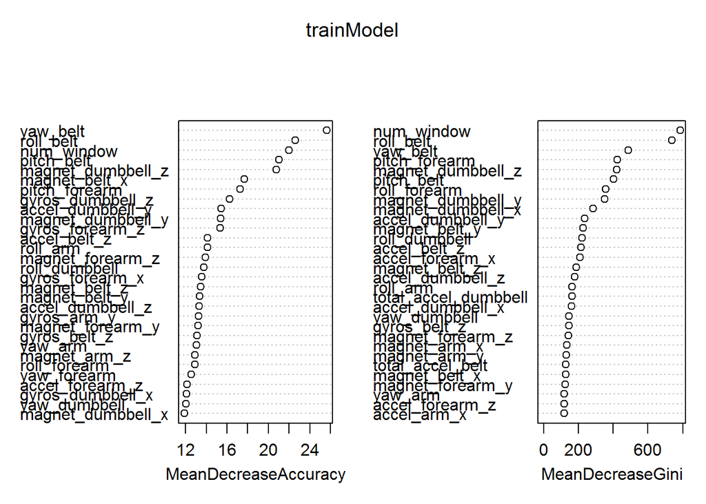

```r
trainModel <- randomForest(classe~., data=train1, importance=TRUE, ntree=100)
varImpPlot(trainModel)
```

Let’s analyze the correlations between these 10 variables. The following code calculates the correlation matrix, replaces the 1s in the diagonal with 0s, and outputs which variables have an absolute value correlation above 75%:

```r
correl = cor(train1[,c("yaw_belt","roll_belt","num_window","pitch_belt","magnet_dumbbell_z","magnet_dumbbell_y","pitch_forearm","accel_dumbbell_y","roll_arm","roll_forearm")])
diag(correl) <- 0
which(abs(correl)>0.75, arr.ind=TRUE)
```

```
##           row col
## roll_belt   2   1
## yaw_belt    1   2
```

So we may have a problem with roll_belt and yaw_belt which have a high correlation (above 75%) with each other:

```r
cor(train1$roll_belt, train1$yaw_belt)
```

```
## [1] 0.8142427
```

These two variables are on top of the Accuracy and Gini graphs, and it may seem scary to eliminate one of them. Let’s be bold and without doing any PCA analysis, we eliminate yaw_belt from the list of 10 variables and concentrate only on the remaining 9 variables.

By re-running the correlation script above (eliminating yaw_belt) and outputting max(correl), we find that the maximum correlation among these 9 variables is 50.57% so we are satisfied with this choice of relatively independent set of covariates.

We can identify an interesting relationship between roll_belt and magnet_dumbbell_y:

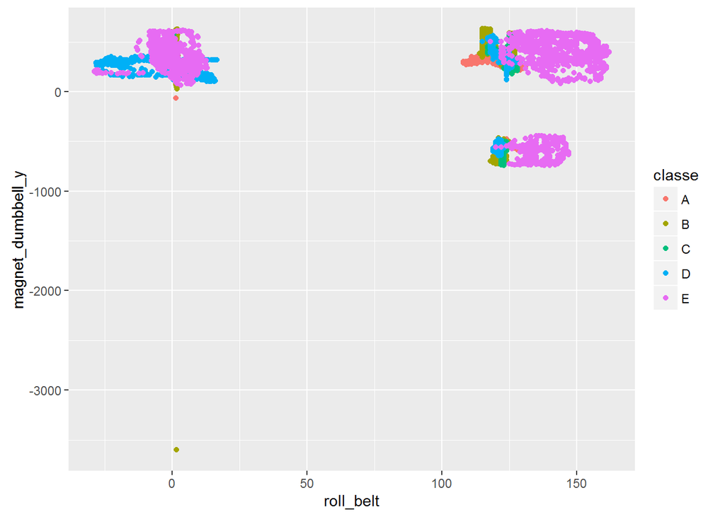

```r
qplot(roll_belt, magnet_dumbbell_y, colour=classe, data=train1)
```

This graph suggests that we could probably categorize the data into groups based on roll_belt values.

Incidentally, a quick tree classifier selects roll_belt as the first discriminant among all 53 covariates (which explains why we have eliminated yaw_belt instead of roll_belt, and not the opposite: it is a “more important” covariate):

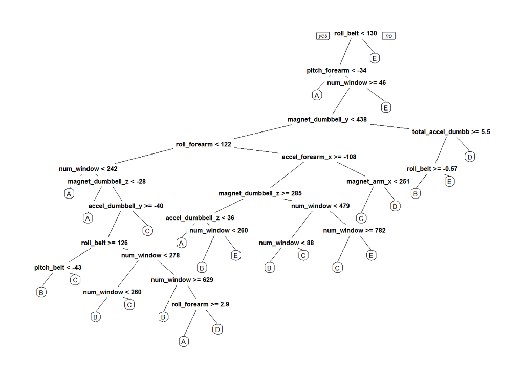

```r
fitModel <- rpart(classe~., data=train1, method="class")
prp(fitModel)
```

# 4. Creation of the Model

We are now ready to create our model. We are using a Random Forest algorithm, using the train() function from the caret package. We are using 9 variables out of the 53 as model parameters. These variables were among the most significant variables generated by an initial Random Forest algorithm, and are roll_belt, num_window, pitch_belt, magnet_dumbbell_y, magnet_dumbbell_z, pitch_forearm, accel_dumbbell_y, roll_arm, and roll_forearm. These variable are relatively independent as the maximum correlation among them is 50.57%. We are using a 2-fold cross-validation control. This is the simplest k-fold cross-validation possible and it will give a reduced computation time. Because the data set is large, using a small number of folds is justified.

```r
fitModel <- train(classe~roll_belt+num_window+pitch_belt+magnet_dumbbell_y+magnet_dumbbell_z+pitch_forearm+accel_dumbbell_y+roll_arm+roll_forearm,
                  data=train1,
                  method="rf",
                  trControl=trainControl(method="cv",number=2),
                  prox=TRUE,
                  verbose=TRUE,
                  allowParallel=TRUE)
```

# 5. Evaluating the Model

## 5.1. Evaluate

```r
predictions <- predict(fitModel, newdata=train2)
confusionMat <- confusionMatrix(predictions, train2$classe)
confusionMat
```

```
## Confusion Matrix and Statistics
##
##           Reference
## Prediction    A    B    C    D    E
##          A 2231    2    0    0    0
##          B    1 1512    1    0    1
##          C    0    4 1367   17    0
##          D    0    0    0 1269    3
##          E    0    0    0    0 1438
##
## Overall Statistics
##
##                Accuracy : 0.9963
##                  95% CI : (0.9947, 0.9975)
##     No Information Rate : 0.2845
##     P-Value [Acc > NIR] : < 2.2e-16
##
##                   Kappa : 0.9953
##  Mcnemar's Test P-Value : NA
##
## Statistics by Class:
##
##                      Class: A Class: B Class: C Class: D Class: E
## Sensitivity            0.9996   0.9960   0.9993   0.9868   0.9972
## Specificity            0.9996   0.9995   0.9968   0.9995   1.0000
## Pos Pred Value         0.9991   0.9980   0.9849   0.9976   1.0000
## Neg Pred Value         0.9998   0.9991   0.9998   0.9974   0.9994
## Prevalence             0.2845   0.1935   0.1744   0.1639   0.1838
## Detection Rate         0.2843   0.1927   0.1742   0.1617   0.1833
## Detection Prevalence   0.2846   0.1931   0.1769   0.1621   0.1833
## Balanced Accuracy      0.9996   0.9978   0.9980   0.9932   0.9986
```

This is a very impressive number for accuracy which totally validates the idea / hypothesis we made to eliminate most variables and use only 9 relatively independent covariates.

## 5.2.Visual Representation of accuracy

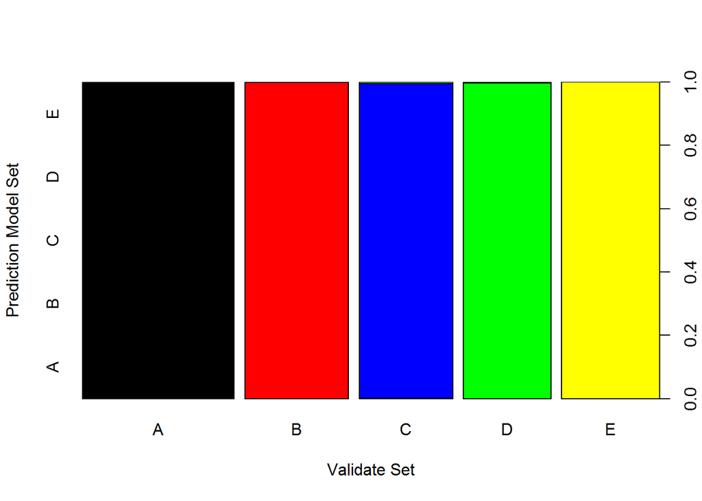

```r
plot(predict(trainModel,newdata=trainingData[,-ncol(trainingData)]),trainingData$classe, xlab="Validate Set", ylab="Prediction Model Set",col = c("black","red", "blue","green","yellow"))
```

Note on Class: * A: Exactly according to the specification * B: Throwing the elbows to the front * C: Lifting the dumbbell only halfway * D: Lowering the dumbbell only halfway * E: Throwing the hips to the front

## 5.3. Estimation of the out-of-sample error rate

The train2 test set was removed and left untouched during variable selection, training and optimizing of the Random Forest algorithm. Therefore this testing subset gives an unbiased estimate of the Random Forest algorithm’s prediction accuracy. The Random Forest’s out-of-sample error rate is calculated.

```r
missClass = function(values, predicted) {
  sum(predicted != values) / length(values)
}
OOS_errRate = missClass(train2$classe, predictions)
OOS_errRate
```

```
## [1] 0.003696151
```

### 5.4. Accuracy of the Model

```r
accurate <- c(as.numeric(predict(trainModel,newdata=trainingData[,-ncol(trainingData)])==trainingData$classe))
MAccuracy <- sum(accurate)*100/nrow(trainingData)
message("Accuracy of Prediction Model set VS Validate Data set = ", format(round(MAccuracy, 2), nsmall=2),"%")
```

```
## Accuracy of Prediction Model set VS Validate Data set = 99.78%
```

# 6.. Conclusion

A nearly 100% accuracy was computed here, but caution must be taken due to the use of Random forest, tends to Overfitting.

# 7.. Predictions on the testing set

```r
# Load test data
testingData  <- read.csv("pml-testing.csv",  na.strings = c("NA", "#DIV/0!", ""))
# Only take the columns of testingData that are also in trainData
testingData <- testingData[ , which(names(testingData) %in% names(trainingData))]# Number of rows:
nrow(testingData)
```

```
## [1] 20
```

```r
test<-predict(trainModel, testingData)
print(test)
```

```
##  1  2  3  4  5  6  7  8  9 10 11 12 13 14 15 16 17 18 19 20
##  B  A  B  A  A  E  D  B  A  A  B  C  B  A  E  E  A  B  B  B
## Levels: A B C D E
```